# Lecture 2, Hour 1: Data Frames

08/30/2015

## Data Frames from Scratch

A data frame in R is an object with 2-dimensional structure: by construction, each column is a variable with its own type and range.

- General case: Column types are unbounded, and can be variables of massive complexity.
- In this class: columns are each of some "atomic" type: numerical, character, factor, logical
- Pieces are joined together in order.

## What R Does

2 sorts of **objects**: **data** and **functions**

- **Data**: things like 7, "seven", \(7.000\), the matrix \(\left[ \begin{array}{ccc} 7 & 7 & 7 \\ 7 & 7 & 7\end{array}\right]\)
- **Functions**: things like \(\log{}\), \(+\) (two arguments), \(<\) (two), \(\mod{}\) (two), `mean` (one)

A function is a machine which turns input objects (**arguments**) into an output object (**return value**), possibly with **side effects**, according to a definite rule

## Data objects

All data is represented in binary format, by **bits** (TRUE/FALSE, YES/NO, 1/0)

- **Booleans/Logicals** Direct binary values: `TRUE` or `FALSE` in R
- **Integers**: whole numbers (positive, negative or zero), represented by a fixed-length block of bits
- **Characters** fixed-length blocks of bits, with special coding; **strings** = sequences of characters
- **Floating point numbers**: a fraction (with a finite number of bits) times an exponent, like \(1.87 \times {10}^{6}\), but in binary form
- **Missing or ill-defined values**: `NA`, `NaN`, etc.

## Constructing Data Frames

Here's a data frame constructed from scratch.

```r
some.states <- data.frame (state=c("Alabama", "Georgia", "Florida"),
                           abbrev = c("AL","GA","FL"),
                           pop = c(4779736, 9687673, 18801310))
str(some.states)
```

```
## 'data.frame':    3 obs. of  3 variables:
##  $ state : Factor w/ 3 levels "Alabama","Florida",..: 1 3 2
##  $ abbrev: Factor w/ 3 levels "AL","FL","GA": 1 3 2
##  $ pop   : num  4779736 9687673 18801310
```

```r
summary(some.states)
```

```
##      state   abbrev      pop
##  Alabama:1   AL:1   Min.   : 4779736
##  Florida:1   FL:1   1st Qu.: 7233704
##  Georgia:1   GA:1   Median : 9687673
##                     Mean   :11089573
##                     3rd Qu.:14244492
##                     Max.   :18801310
```

## Loading in outside sources

```r
all.states <- read.csv ("NewStates.csv")
head(all.states, 2)
```

```
##     State   Area AreaRank pop2005 pop2004 pop2000 pop1990    zone
## 1 Alabama  52419       30    4558    4525    4447    4040  ESCent
## 2  Alaska 663267        1     664     658     627     550 Pacific
```

## Basic Operations: Row Subsets By Condition

Three methods:

```r
all.states[all.states$zone == "ESCent",]
```

```
##          State  Area AreaRank pop2005 pop2004 pop2000 pop1990   zone
## 1      Alabama 52419       30    4558    4525    4447    4040 ESCent
## 18    Kentucky 40409       37    4173    4142    4042    3687 ESCent
## 25 Mississippi 48430       32    2921    2901    2845    2575 ESCent
## 43   Tennessee 42143       36    5963    5893    5689    4877 ESCent
```

```r
subset (all.states, zone == "ESCent")
```

```
##          State  Area AreaRank pop2005 pop2004 pop2000 pop1990   zone
## 1      Alabama 52419       30    4558    4525    4447    4040 ESCent
## 18    Kentucky 40409       37    4173    4142    4042    3687 ESCent
## 25 Mississippi 48430       32    2921    2901    2845    2575 ESCent
## 43   Tennessee 42143       36    5963    5893    5689    4877 ESCent
```

```r
library(dplyr)
filter (all.states, zone == "ESCent")
```

```
##         State  Area AreaRank pop2005 pop2004 pop2000 pop1990   zone
## 1     Alabama 52419       30    4558    4525    4447    4040 ESCent
## 2    Kentucky 40409       37    4173    4142    4042    3687 ESCent
## 3 Mississippi 48430       32    2921    2901    2845    2575 ESCent
## 4   Tennessee 42143       36    5963    5893    5689    4877 ESCent
```

## Basic Operations: Row Subsets By Position

```r
all.states[3:5,]
```

```
##        State   Area AreaRank pop2005 pop2004 pop2000 pop1990     zone
## 3    Arizona 113998        6    5939    5740    5131    3665 Mountain
## 4   Arkansas  53179       29    2779    2750    2673    2351   WSCent
## 5 California 163696        3   36132   35842   33872   29811  Pacific
```

```r
slice (all.states, 3:5)
```

```
##        State   Area AreaRank pop2005 pop2004 pop2000 pop1990     zone
## 1    Arizona 113998        6    5939    5740    5131    3665 Mountain
## 2   Arkansas  53179       29    2779    2750    2673    2351   WSCent
## 3 California 163696        3   36132   35842   33872   29811  Pacific
```

```r
all.states[13,]
```

```
##    State  Area AreaRank pop2005 pop2004 pop2000 pop1990     zone
## 13 Idaho 83570       14    1429    1395    1294    1007 Mountain
```

```r
slice (all.states, 13)
```

```
##   State  Area AreaRank pop2005 pop2004 pop2000 pop1990     zone
## 1 Idaho 83570       14    1429    1395    1294    1007 Mountain
```

## Basic Operations: Column Subsets

Number of column:

```r
all.states[[2]]
```

```
##  [1]  52419 663267 113998  53179 163696 104094   5543   2489     68  65755
## [11]  59425  10931  83570  57914  36418  56272  82277  40409  51840  35385
## [21]  12407  10555  96716  86939  48430  69704 147042  77354 110561   9350
## [31]   8721 121590  54556  53819  70700  44825  69898  98381  46055   1545
## [41]  32020  77117  42143 268581  84899   9614  42774  71300  24230  65498
## [51]  97814
```

Name of column:

```r
all.states[["Area"]]
```

```
##  [1]  52419 663267 113998  53179 163696 104094   5543   2489     68  65755
## [11]  59425  10931  83570  57914  36418  56272  82277  40409  51840  35385
## [21]  12407  10555  96716  86939  48430  69704 147042  77354 110561   9350
## [31]   8721 121590  54556  53819  70700  44825  69898  98381  46055   1545
## [41]  32020  77117  42143 268581  84899   9614  42774  71300  24230  65498
## [51]  97814
```

```r
all.states[,"Area"]
```

```
##  [1]  52419 663267 113998  53179 163696 104094   5543   2489     68  65755
## [11]  59425  10931  83570  57914  36418  56272  82277  40409  51840  35385
## [21]  12407  10555  96716  86939  48430  69704 147042  77354 110561   9350
## [31]   8721 121590  54556  53819  70700  44825  69898  98381  46055   1545
## [41]  32020  77117  42143 268581  84899   9614  42774  71300  24230  65498
## [51]  97814
```

Reduces this to a vector; removes geometry.

## Basic Operations: Column Subsets

dplyr:

```r
head(select (all.states, Area), 5)
```

```
##     Area
## 1  52419
## 2 663267
## 3 113998
## 4  53179
## 5 163696
```

## Basic Operations: Sorting

Let's take a subset of states.

```r
WSCent <- filter (all.states, zone == "WSCent")
WSCent
```

```
##       State   Area AreaRank pop2005 pop2004 pop2000 pop1990   zone
## 1  Arkansas  53179       29    2779    2750    2673    2351 WSCent
## 2 Louisiana  51840       31    4524    4507    4469    4222 WSCent
## 3  Oklahoma  69898       20    3548    3524    3451    3146 WSCent
## 4     Texas 268581        2   22860   22472   20852   16986 WSCent
```

```r
arrange (WSCent, pop2005)
```

```
##       State   Area AreaRank pop2005 pop2004 pop2000 pop1990   zone
## 1  Arkansas  53179       29    2779    2750    2673    2351 WSCent
## 2  Oklahoma  69898       20    3548    3524    3451    3146 WSCent
## 3 Louisiana  51840       31    4524    4507    4469    4222 WSCent
## 4     Texas 268581        2   22860   22472   20852   16986 WSCent
```

## Basic Operations: Sorting

Let's take a subset of states.

```r
arrange (WSCent, desc(pop2005))
```

```
##       State   Area AreaRank pop2005 pop2004 pop2000 pop1990   zone
## 1     Texas 268581        2   22860   22472   20852   16986 WSCent
## 2 Louisiana  51840       31    4524    4507    4469    4222 WSCent
## 3  Oklahoma  69898       20    3548    3524    3451    3146 WSCent
## 4  Arkansas  53179       29    2779    2750    2673    2351 WSCent
```

```r
top_n (WSCent, 2, pop2005)
```

```
##       State   Area AreaRank pop2005 pop2004 pop2000 pop1990   zone
## 1 Louisiana  51840       31    4524    4507    4469    4222 WSCent
## 2     Texas 268581        2   22860   22472   20852   16986 WSCent
```

## "Pipe" operator

Rather than nesting terms explicitly, the "pipe" from the R package `magrittr` helps to clean up syntax.

Default: make the item you "pipe" the first argument of the next function (parentheses optional, but helpful)

```r
sqrt(81)
```

```
## [1] 9
```

```r
81 %>% sqrt
```

```
## [1] 9
```

```r
65536 %>% sqrt()
```

```
## [1] 256
```

If you don't want the first argument, use the placeholder `.` to mark the item you want replaced.

```r
pnorm(0.5, 0, 2)
```

```
## [1] 0.5987063
```

```r
2 %>% pnorm(0.5, 0, .)
```

```
## [1] 0.5987063
```

## Group operations

Why this is so useful for our purposes: inline grouping by "key"(s). `group_by` function

```r
top_n(group_by(all.states, zone), 1, pop2005)
```

```
## Source: local data frame [9 x 8]
## Groups: zone
##
##           State   Area AreaRank pop2005 pop2004 pop2000 pop1990
## 1       Arizona 113998        6    5939    5740    5131    3665
## 2    California 163696        3   36132   35842   33872   29811
## 3       Florida  65755       22   17790   17385   15983   12938
## 4      Illinois  57914       25   12763   12712   12420   11431
## 5 Massachusetts  10555       44    6399    6407    6349    6016
## 6      Missouri  69704       21    5800    5760    5597    5117
## 7      New York  54556       27   19255   19281   18977   17991
## 8     Tennessee  42143       36    5963    5893    5689    4877
## 9         Texas 268581        2   22860   22472   20852   16986
## Variables not shown: zone (fctr)
```

## Group operations

Combine this with the pipe and the order of operations is clear.

```r
all.states %>% group_by (zone) %>% top_n (1, pop2005)
```

```
## Source: local data frame [9 x 8]
## Groups: zone
##
##           State   Area AreaRank pop2005 pop2004 pop2000 pop1990
## 1       Arizona 113998        6    5939    5740    5131    3665
## 2    California 163696        3   36132   35842   33872   29811
## 3       Florida  65755       22   17790   17385   15983   12938
## 4      Illinois  57914       25   12763   12712   12420   11431
## 5 Massachusetts  10555       44    6399    6407    6349    6016
## 6      Missouri  69704       21    5800    5760    5597    5117
## 7      New York  54556       27   19255   19281   18977   17991
## 8     Tennessee  42143       36    5963    5893    5689    4877
## 9         Texas 268581        2   22860   22472   20852   16986
## Variables not shown: zone (fctr)
```

## Group operations

Bottom up:

```r
all.states %>% group_by (zone) %>% top_n (1, desc(pop2005))
```

```
## Source: local data frame [9 x 8]
## Groups: zone
##
##                  State   Area AreaRank pop2005 pop2004 pop2000 pop1990
## 1               Alaska 663267        1     664     658     627     550
## 2             Arkansas  53179       29    2779    2750    2673    2351
## 3 District of Columbia     68      (X)     551     554     572     607
## 4              Indiana  36418       38    6272    6227    6081    5544
## 5          Mississippi  48430       32    2921    2901    2845    2575
## 6           New Jersey   8721       47    8718    8685    8414    7748
## 7         North Dakota  70700       19     637     636     642     639
## 8              Vermont   9614       45     623     621     609     563
## 9              Wyoming  97814       10     509     506     494     454
## Variables not shown: zone (fctr)
```

## Group operations

Combine this with the pipe and the order of operations is clear.

```r
all.states %>% group_by (zone) %>% top_n (1, pop2005) %>% ungroup %>% arrange(zone)
```

```
## Source: local data frame [9 x 8]
##
##           State   Area AreaRank pop2005 pop2004 pop2000 pop1990
## 1      Illinois  57914       25   12763   12712   12420   11431
## 2     Tennessee  42143       36    5963    5893    5689    4877
## 3      New York  54556       27   19255   19281   18977   17991
## 4       Arizona 113998        6    5939    5740    5131    3665
## 5 Massachusetts  10555       44    6399    6407    6349    6016
## 6    California 163696        3   36132   35842   33872   29811
## 7       Florida  65755       22   17790   17385   15983   12938
## 8      Missouri  69704       21    5800    5760    5597    5117
## 9         Texas 268581        2   22860   22472   20852   16986
## Variables not shown: zone (fctr)
```

## Group operations

Bottom up:

```r
all.states %>% group_by (zone) %>% top_n (1, desc(pop2005)) %>% ungroup %>% arrange(zone)
```

```
## Source: local data frame [9 x 8]
##
##                  State   Area AreaRank pop2005 pop2004 pop2000 pop1990
## 1              Indiana  36418       38    6272    6227    6081    5544
## 2          Mississippi  48430       32    2921    2901    2845    2575
## 3           New Jersey   8721       47    8718    8685    8414    7748
## 4              Wyoming  97814       10     509     506     494     454
## 5              Vermont   9614       45     623     621     609     563
## 6               Alaska 663267        1     664     658     627     550
## 7 District of Columbia     68      (X)     551     554     572     607
## 8         North Dakota  70700       19     637     636     642     639
## 9             Arkansas  53179       29    2779    2750    2673    2351
## Variables not shown: zone (fctr)
```

## Group summaries

Let's get some summary statistics on our group of US States.

```r
all.states %>% summarize (totalpop2005=sum(pop2005),
                          count=n(),
                          Area=sum(Area))
```

```
##   totalpop2005 count    Area
## 1       296412    51 3794087
```

Grouping by zone:

```r
all.states %>% group_by (zone) %>%
  summarize (totalpop2005=sum(pop2005),
             count=n(),
             Area=sum(Area))
```

```
## Source: local data frame [9 x 4]
##
##             zone totalpop2005 count    Area
## 1         ENCent        40620     4  235873
## 2         ESCent        17615     4  183401
## 3 MiddleAtlantic        40403     3  109332
## 4       Mountain        20291     8  863568
## 5     NewEngland        14240     6   71992
## 6        Pacific        48000     5 1007575
## 7  SouthAtlantic        56180     9  292987
## 8         WNCent        25352     8  585861
## 9         WSCent        33711     4  443498
```

## Group summaries

Let's add some more categories for building a new data frame:

```r
all.states %>% group_by (zone) %>%
  summarize (totalpop2005=sum(pop2005),
             count=n(),
             Area=sum(Area),
             meanpop2005 = mean(pop2005),
             sdpop2005 = sd(pop2005))
```

```
## Source: local data frame [9 x 6]
##
##             zone totalpop2005 count    Area meanpop2005 sdpop2005
## 1         ENCent        40620     4  235873   10155.000  2804.401
## 2         ESCent        17615     4  183401    4403.750  1252.577
## 3 MiddleAtlantic        40403     3  109332   13467.667  5344.591
## 4       Mountain        20291     8  863568    2536.375  1866.849
## 5     NewEngland        14240     6   71992    2373.333  2212.723
## 6        Pacific        48000     5 1007575    9600.000 14996.531
## 7  SouthAtlantic        56180     9  292987    6242.222  5414.700
## 8         WNCent        25352     8  585861    3169.000  2095.189
## 9         WSCent        33711     4  443498    8427.750  9647.961
```

## Spread and Gather

This data frame is "tidy" if our experimental unit is "state". What about "state-year"? Recall

```r
WSCent
```

```
##       State   Area AreaRank pop2005 pop2004 pop2000 pop1990   zone
## 1  Arkansas  53179       29    2779    2750    2673    2351 WSCent
## 2 Louisiana  51840       31    4524    4507    4469    4222 WSCent
## 3  Oklahoma  69898       20    3548    3524    3451    3146 WSCent
## 4     Texas 268581        2   22860   22472   20852   16986 WSCent
```

Use "gather"

```r
library(tidyr)
longtable <- gather (WSCent,  ## data frame for input.
                     year,    ## name for the "key"
                     population, ## name for the "value"
                     pop2005:pop1990)  ## columns to gather.
longtable
```

```
##        State   Area AreaRank   zone    year population
## 1   Arkansas  53179       29 WSCent pop2005       2779
## 2  Louisiana  51840       31 WSCent pop2005       4524
## 3   Oklahoma  69898       20 WSCent pop2005       3548
## 4      Texas 268581        2 WSCent pop2005      22860
## 5   Arkansas  53179       29 WSCent pop2004       2750
## 6  Louisiana  51840       31 WSCent pop2004       4507
## 7   Oklahoma  69898       20 WSCent pop2004       3524
## 8      Texas 268581        2 WSCent pop2004      22472
## 9   Arkansas  53179       29 WSCent pop2000       2673
## 10 Louisiana  51840       31 WSCent pop2000       4469
## 11  Oklahoma  69898       20 WSCent pop2000       3451
## 12     Texas 268581        2 WSCent pop2000      20852
## 13  Arkansas  53179       29 WSCent pop1990       2351
## 14 Louisiana  51840       31 WSCent pop1990       4222
## 15  Oklahoma  69898       20 WSCent pop1990       3146
## 16     Texas 268581        2 WSCent pop1990      16986
```

## Spread and Gather

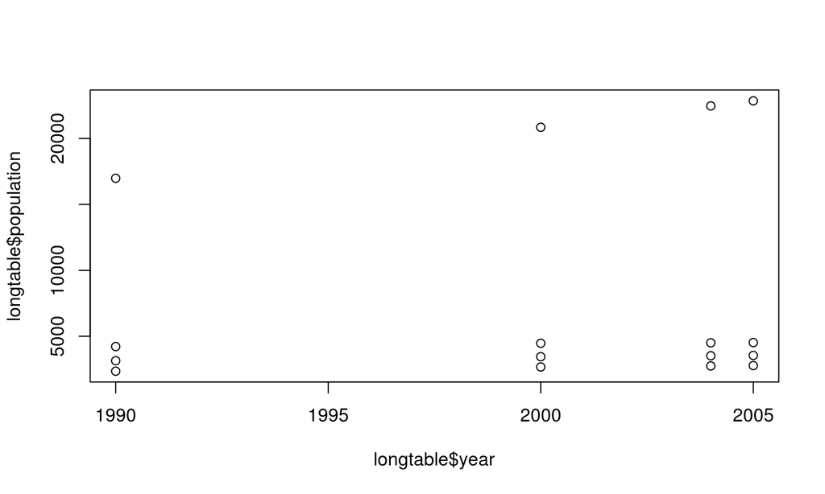

```r
longtable <- longtable %>% mutate (year = substr(year, 4, 7))
plot(longtable$year, longtable$population)
```

## Spread and Gather

```r
widetable <- longtable %>% spread (year, population)
widetable
```

```
##       State   Area AreaRank   zone  1990  2000  2004  2005
## 1  Arkansas  53179       29 WSCent  2351  2673  2750  2779
## 2 Louisiana  51840       31 WSCent  4222  4469  4507  4524
## 3  Oklahoma  69898       20 WSCent  3146  3451  3524  3548
## 4     Texas 268581        2 WSCent 16986 20852 22472 22860
```

## Setting up lagged data

We have lagged data implicitly in this table, but putting it in the long form would be useful too:

```r
longtable.2 <- longtable %>% group_by (State) %>% mutate (lagpop = lag(population))
head(longtable.2)
```

```
## Source: local data frame [6 x 7]
## Groups: State
##
##       State   Area AreaRank   zone year population lagpop
## 1  Arkansas  53179       29 WSCent 2005       2779     NA
## 2 Louisiana  51840       31 WSCent 2005       4524     NA
## 3  Oklahoma  69898       20 WSCent 2005       3548     NA
## 4     Texas 268581        2 WSCent 2005      22860     NA
## 5  Arkansas  53179       29 WSCent 2004       2750  22860
## 6 Louisiana  51840       31 WSCent 2004       4507   2750
```

## Setting up lagged data

Whoops! Have to put it in order first because `lag()` doesn't care about numerical order, just vector order.

```r
longtable.2 <- longtable %>% arrange (year) %>% group_by (State) %>% mutate (lagpop = lag(population))
head(longtable.2)
```

```
## Source: local data frame [6 x 7]
## Groups: State
##
##       State   Area AreaRank   zone year population lagpop
## 1  Arkansas  53179       29 WSCent 1990       2351     NA
## 2 Louisiana  51840       31 WSCent 1990       4222     NA
## 3  Oklahoma  69898       20 WSCent 1990       3146     NA
## 4     Texas 268581        2 WSCent 1990      16986     NA
## 5  Arkansas  53179       29 WSCent 2000       2673  16986
## 6 Louisiana  51840       31 WSCent 2000       4469   2673
```

## Let's add to it and check it.

```r
longtable.2 <- longtable %>% arrange (year) %>% group_by (State) %>%
  mutate (lagpop = lag(population),
          growthrate = population/lagpop) %>% ungroup
slice(longtable.2, 5:8)
```

```
## Source: local data frame [4 x 8]
##
##       State   Area AreaRank   zone year population lagpop growthrate
## 1  Arkansas  53179       29 WSCent 2000       2673  16986  0.1573649
## 2 Louisiana  51840       31 WSCent 2000       4469   2673  1.6719042
## 3  Oklahoma  69898       20 WSCent 2000       3451   4469  0.7722085
## 4     Texas 268581        2 WSCent 2000      20852   3451  6.0423066
```

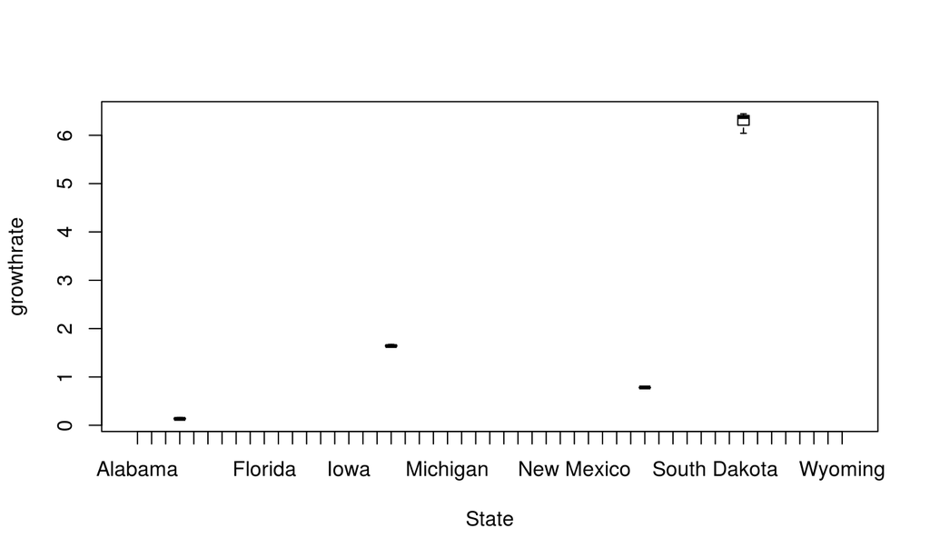

```r
plot(growthrate ~ State, data = longtable.2)
```